# Income Model: Model Selection and Implementation

Author

Group 5

Published

October 4, 2026

## Run this if you need the packages

```r
# Only needed if the packages are not installed yet: remove the # in front of
# install.packages(c("tidyverse", "survey", "ranger"))
```

## About this file

This file covers model selection and implementation for the **income question**. It follows the same structure as `3.1) Employment Model.qmd`.It chooses the candidate models, explains why each one was chosen and fits them to the training data.

As with the employment models, **the test set is not used here** and no parameters are tuned. Each model is fitted once with documented starting parameters and saved to `Models/`, for tuning and evaluation in the evaluation notebook. The reasoning is also written up in `Milestone 3 Submit.docx` (in `Documentation/Milestone Documentation/Milestone 3/`).

## How this notebook works

The steps are the same as in `3.1) Employment Model.qmd`:

1. **Load the shared setup** with `source("R/model_preparation.R")`, which gives the notebook the predictor lists, the formulas and `prepare_income_data()`.
2. **Prepare the training data** with `prepare_income_data()`, which reads `income_train.csv` the same way in every notebook.
3. **Fit two models** parameters that work as in the employment models are only briefly commented here the differences are explained in full.
4. **Save** both models to `Models/` and check that they reload with identical predictions.
5. `3.3) Model Evaluation.qmd` then tunes and tests them.

| Model | Function | What fitting does | What comes out |
| --- | --- | --- | --- |
| Linear regression | `survey::svyglm()` | Finds the coefficients that make the predicted `log_salary` as close as possible to the actual values (least squares), using the survey weights | One coefficient per predictor, readable as a percentage difference in salary |
| Random forest | `ranger::ranger()` | Grows 500 regression trees on random resamples and averages their predicted `log_salary` | Predicted `log_salary`, and a ranking of how much each predictor is used |

**Formulas.** The `+` and `*` work exactly as explained with the four-group tables in `3.1) Employment Model.qmd` (and in `Scripts/R/model_preparation.R`), but the outcome is salary instead of employment:

- **With `+`**, the salary difference that goes with home internet is forced to be the same for people with and without matric.
- **With `*`**, the regression adds a fourth number for people with **both** matric and home internet. Above zero means the salary premium for matric is larger in connected households (complements) while below zero means it is smaller (substitutes).

The linear regression uses `matric_plus * any_home_internet` and `+` for the six controls. The random forest uses `+` only, because its trees find interactions themselves.

## Loading the packages we need

```r
library(tidyverse) # data handling (also loaded by the preparation script)
library(survey)    # svyglm(): linear regression with survey weights and household clustering
library(ranger)    # random forest
```

## File paths

```r
analytical_directory <- "../Datasets/Analytical/"
model_directory <- "../Models/"

dir.create(model_directory, showWarnings = FALSE) # created on the first run only
```

# 1. Analytical question and modelling task

In Milestone 1 the question whether internet access is associated with higher income among those who report it was one of the goals of this project, and to address it the following model was created.

- **Modelling task:** **regression**. The outcome `log_salary` is the natural log of the monthly salary, which is continuous.
- **Population:** employed people who reported a salary of at least R100, from `income_train.csv`.
- **What the models must deliver:** an estimate of how much higher salaries are, on average, with matric and with home internet, including whether the two together are associated with more than the sum of their separate effects.

This question is **exploratory**. Salaries are missing for a large share of employed people, and people who report a salary may differ from those who do not. So with these missing values we cannot conclusively determine whether salary is better with internet and education or not, we can merely explore the data provided.

# 2. Data and predictors

## 2.1 Reading the training data

The data is read through `prepare_income_data()` in `Scripts/R/model_preparation.R`, which the evaluation notebook and the Shiny app also use. It reads `household_id` as text, applies the fixed category levels and leaves out people with unknown education (`matric_plus` blank) or unknown household internet (`any_home_internet` blank).

```r
source("R/model_preparation.R")

# Raw file, only to count the rows before preparation
income_train_raw <- read_csv(
  file.path(analytical_directory, "income_train.csv"),
  col_types = cols(household_id = col_character()),
  show_col_types = FALSE
)

income_train <- prepare_income_data(file.path(analytical_directory, "income_train.csv"))
```

```r
tibble(
  check = c(
    "Rows in income_train.csv",
    "Rows removed: unknown education or unknown household internet",
    "Rows used for model fitting",
    "Households used for model fitting",
    "Missing values left in the predictors or outcome"
  ),
  value = c(
    nrow(income_train_raw),
    nrow(income_train_raw) - nrow(income_train),
    nrow(income_train),
    n_distinct(income_train$household_id),
    sum(is.na(select(income_train, -household_id, -person_weight)))
  )
)
```

| check | value |
| --- | --- |
| Rows in income_train.csv | 14371 |
| Rows removed: unknown education or unknown household internet | 316 |
| Rows used for model fitting | 14055 |
| Households used for model fitting | 10272 |
| Missing values left in the predictors or outcome | 0 |

## 2.2 The outcome

Salaries are strongly right-skewed: a few very high salaries would dominate a model of the raw amounts. Milestone 2 therefore created `log_salary`. On the log scale the distribution is close to symmetric, which suits linear regression, and a coefficient *b* can be read as a percentage difference in salary: exp(*b*) − 1.

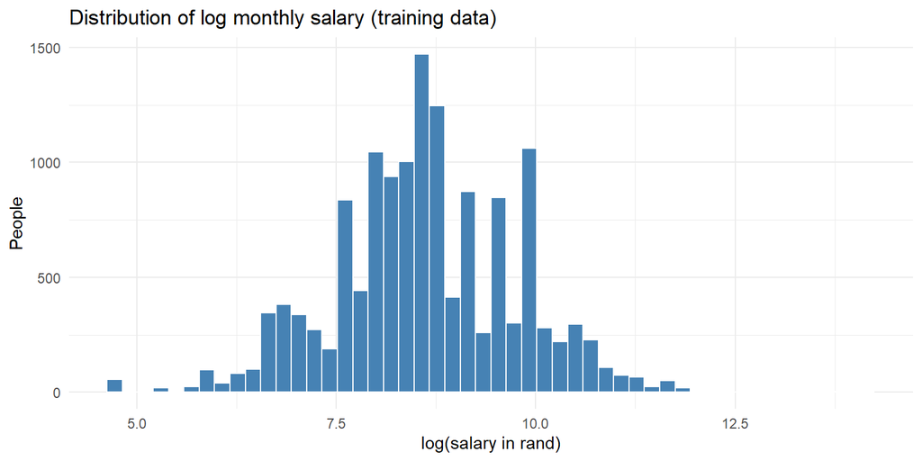

```r
ggplot(income_train, aes(x = log_salary)) +
  geom_histogram(bins = 50, fill = "steelblue", colour = "white") +
  labs(
    title = "Distribution of log monthly salary (training data)",
    x = "log(salary in rand)",
    y = "People"
  ) +
  theme_minimal()
```

## 2.3 Choosing the predictors

`income_data.csv` has fewer candidate predictors than `model_data.csv`: it was built with the education, digital-access and demographic columns only. The same choices are made as for the employment model, so the two models can be compared:

| Kept | Left out | Reason |
| --- | --- | --- |
| `matric_plus` | `education_band` | One 0/1 education variable gives one interaction coefficient, the same question as in the employment model. |
| `any_home_internet` | `digital_access_score` | `digital_access_score` includes internet access, so using both would count it twice. `any_home_internet` is also the column used in the employment model. |
| `age_centred`, `age_centred_squared` |  | Salaries rise with experience and level off, a curved pattern that the squared term allows for. |
| `female`, `population_group`, `province`, `settlement_type` |  | Controls for the gender pay gap, historical inequality and regional wage differences. Without them, the internet effect would partly be one of these. `population_group` is a sensitive attribute, used … |

As in the employment model, `household_id` and `person_weight` are design columns, not predictors.

Each combination of matric and internet access has enough people to estimate the interaction:

```r
income_train |>
  count(matric_plus, any_home_internet, name = "people")
```

| matric_plus | any_home_internet | people |
| --- | --- | --- |
| 0 | 0 | 1285 |
| 0 | 1 | 4410 |
| 1 | 0 | 555 |
| 1 | 1 | 7805 |

# 3. Candidate models

| Model | Package | Role | Why it suits this problem |
| --- | --- | --- | --- |
| **1. Survey-weighted linear regression** | `survey::svyglm()` | Main explanatory model | Estimates the education × internet interaction directly, as a percentage difference in salary with a confidence interval and significance test. It uses the survey weights and household clustering, lik… |
| **2. Random forest (regression)** | `ranger::ranger()` | Predictive benchmark and robustness check | Allows non-linear effects and any interactions. It shows whether the linear model misses important structure, and whether education and internet remain important predictors of income without the linea… |

Models considered but not used:

- **Gamma or log-normal GLM on the raw salary:** gives similar answers as a linear model of `log_salary`, but is harder to explain.
- **Quantile regression:** would show effects at low and high salaries separately. It could be used as a possible extension, but is not needed here.

# 4. Model 1: Survey-weighted linear regression

## 4.1 Assumptions and parameter choices

| Assumption | How it is handled |
| --- | --- |
| Linear relationship with the numeric predictors | Age enters as a linear and a squared term. The other predictors are 0/1 or categorical, so linearity does not apply to them. |
| Roughly normal, constant-variance errors | The log transformation makes salaries roughly symmetric. The residuals are checked during evaluation. |
| Independent observations | Household members share household-level predictors, so households are the clusters in the survey design, and the standard errors allow for this. |
| No strong multicollinearity | Overlapping columns were left out. |
| Representative estimates | `person_weight` makes the estimates describe the salaried population rather than the sample. |

Parameter choices: `family = gaussian()` (ordinary linear regression), with the design `ids = ~household_id, weights = ~person_weight`. The interaction `matric_plus * any_home_internet` is included as in the employment model. On the log scale, a positive interaction coefficient means the salary premium for matric is larger in connected households (complements), and a negative one means it is smaller (substitutes). There are no hyperparameters to tune.

## 4.2 Fitting the model

```r
# Survey design, as in the employment model: households as clusters, person_weight as the survey weight
income_design <- svydesign(
  ids = ~household_id,
  weights = ~person_weight,
  data = income_train
)

income_linear <- svyglm(
  income_regression_formula, # log_salary ~ matric_plus * any_home_internet + the 6 controls (R/model_preparation.R)
  design = income_design,
  family = gaussian()
)

income_regression_formula # prints the formula in full
```

```
log_salary ~ matric_plus * any_home_internet + age_centred +
    age_centred_squared + female + population_group + province +
    settlement_type
```

## 4.3 Fitted coefficients

Each coefficient is shown on the log scale and as a percentage difference in salary, with 95% confidence intervals. Interpreting the results is part of evaluation.

```r
coefficient_table <- summary(income_linear)$coefficients
confidence_limits <- confint(income_linear) # Wald intervals, using the clustered standard errors

tibble(
  term = rownames(coefficient_table),
  estimate = coefficient_table[, "Estimate"],
  # exp(b) - 1 turns a log-scale coefficient into a percentage difference in salary
  percent_difference = 100 * (exp(coefficient_table[, "Estimate"]) - 1),
  ci_lower_percent = 100 * (exp(confidence_limits[, 1]) - 1),
  ci_upper_percent = 100 * (exp(confidence_limits[, 2]) - 1),
  p_value = coefficient_table[, "Pr(>|t|)"]
) |>
  mutate(across(estimate:ci_upper_percent, \(x) round(x, 3)),
         p_value = format.pval(p_value, digits = 3, eps = 0.0001)) # very small p-values show as "<1e-04"
```

| term | estimate | percent_difference | ci_lower_percent | ci_upper_percent | p_value |
| --- | --- | --- | --- | --- | --- |
| (Intercept) | 8.002 | 298542.127 | 278148.364 | 320430.618 | < 1e-04 |
| matric_plus | 0.723 | 106.016 | 85.041 | 129.369 | < 1e-04 |
| any_home_internet | 0.500 | 64.808 | 54.115 | 76.243 | < 1e-04 |
| age_centred | 0.018 | 1.787 | 1.616 | 1.959 | < 1e-04 |
| age_centred_squared | -0.001 | -0.069 | -0.084 | -0.055 | < 1e-04 |
| female | -0.170 | -15.652 | -18.365 | -12.848 | < 1e-04 |
| population_groupColoured | 0.257 | 29.255 | 19.558 | 39.739 | < 1e-04 |
| population_groupIndian/Asian | 0.625 | 86.823 | 56.630 | 122.835 | < 1e-04 |
| population_groupWhite | 0.988 | 168.708 | 149.021 | 189.952 | < 1e-04 |
| provinceWestern Cape | 0.090 | 9.428 | 1.971 | 17.430 | 0.01235 |
| provinceEastern Cape | -0.063 | -6.119 | -13.032 | 1.345 | 0.10571 |
| provinceNorthern Cape | 0.110 | 11.679 | -1.751 | 26.944 | 0.09107 |
| provinceFree State | -0.116 | -10.924 | -19.234 | -1.758 | 0.02062 |
| provinceKwaZulu-Natal | -0.107 | -10.191 | -16.622 | -3.264 | 0.00458 |
| provinceNorth West | 0.133 | 14.270 | 2.852 | 26.956 | 0.01302 |
| provinceMpumalanga | 0.037 | 3.774 | -5.126 | 13.510 | 0.41803 |
| provinceLimpopo | 0.218 | 24.323 | 13.917 | 35.679 | < 1e-04 |
| settlement_typeNon-metro urban | -0.221 | -19.794 | -24.236 | -15.090 | < 1e-04 |
| settlement_typeTraditional | -0.510 | -39.928 | -44.054 | -35.498 | < 1e-04 |
| settlement_typeFarms | -0.154 | -14.259 | -21.914 | -5.854 | 0.00127 |
| matric_plus:any_home_internet | 0.030 | 3.088 | -8.010 | 15.525 | 0.60073 |

The intercept is on the log scale, and its percentage column has no meaning.

```r
tibble(
  check = c("Rows used in the fit", "Coefficients estimated", "Coefficients not estimated (NA)"),
  value = c(
    nobs(income_linear),
    length(coef(income_linear)),
    sum(is.na(coef(income_linear)))
  )
)
```

| check | value |
| --- | --- |
| Rows used in the fit | 14055 |
| Coefficients estimated | 21 |
| Coefficients not estimated (NA) | 0 |

# 5. Model 2: Random forest (regression)

## 5.1 Assumptions and parameter choices

The regression forest works like the employment forest, but each tree predicts the average `log_salary` of the people in its leaf rather than a class probability, and the forest averages those predictions. It makes no assumptions about the shape of the effects.

Starting parameters (to be tuned in the evaluation notebook):

| Parameter | Value | Reason |
| --- | --- | --- |
| `num.trees` | 500 | Enough trees for the predictions and importance scores to stabilise. |
| `mtry` | 2 | Predictors considered at each split: the standard one third of the 8 predictors for regression. The main tuning parameter. |
| `min.node.size` | 5 | The standard minimum leaf size for regression forests. |
| `respect.unordered.factors` | `"order"` | Orders the levels of each categorical predictor by their average salary before splitting, instead of treating their alphabetical order as meaningful. |
| `importance` | `"permutation"` | Measures how much the predictions worsen when a predictor’s values are shuffled. |
| `seed` | 67 | Makes the forest reproducible. |

Survey weights are not used, for the reason given in the employment model: `ranger` would use them as bootstrap sampling probabilities, so a few heavily weighted people would appear in almost every tree.

## 5.2 Fitting the model

```r
income_forest <- ranger(
  income_tree_formula,
  data = income_train,
  num.trees = 500,
  mtry = 2,
  min.node.size = 5,
  respect.unordered.factors = "order",
  importance = "permutation",
  seed = 67
)
# No probability = TRUE: with a numeric outcome the forest averages the trees' predicted log_salary
```

## 5.3 Variable importance

```r
tibble(
  predictor = names(importance(income_forest)),
  permutation_importance = importance(income_forest)
) |>
  arrange(desc(permutation_importance)) |>
  mutate(permutation_importance = signif(permutation_importance, 3))
```

| predictor | permutation_importance |
| --- | --- |
| matric_plus | 0.2950 |
| population_group | 0.1980 |
| settlement_type | 0.1010 |
| age_centred | 0.0885 |
| province | 0.0794 |
| any_home_internet | 0.0698 |
| age_centred_squared | 0.0297 |
| female | 0.0236 |

Importance shows how much the forest *uses* a predictor, not the direction of its effect and not a causal effect.

# 6. Saving the models and handing over to evaluation

```r
saveRDS(income_linear, file.path(model_directory, "income_linear.rds"))
saveRDS(income_forest, file.path(model_directory, "income_forest.rds"))

tibble(
  file = c("income_linear.rds", "income_forest.rds"),
  size_mb = round(file.size(file.path(model_directory, file)) / 1024^2, 1)
)
```

| file | size_mb |
| --- | --- |
| income_linear.rds | 3.4 |
| income_forest.rds | 4.3 |

The saved models are read back to confirm that they give the same predictions as the models in memory:

```r
check_rows <- head(income_train, 20)

tibble(
  model = c("Linear regression", "Random forest"),
  predictions_identical = c(
    identical(
      as.numeric(predict(income_linear, check_rows)),
      as.numeric(predict(readRDS(file.path(model_directory, "income_linear.rds")), check_rows))
    ),
    identical(
      predict(income_forest, check_rows)$predictions,
      predict(readRDS(file.path(model_directory, "income_forest.rds")), check_rows)$predictions
    )
  )
)
```

| model | predictions_identical |
| --- | --- |
| Linear regression | TRUE |
| Random forest | TRUE |

## Handover to tuning and evaluation

**Preparing the test set** with the same function:

```r
source("R/model_preparation.R")
income_test <- prepare_income_data("../Datasets/Analytical/income_test.csv")
```

**Getting predicted `log_salary`** from each saved model:

```r
income_linear <- readRDS("../Models/income_linear.rds")
income_forest <- readRDS("../Models/income_forest.rds")

pred_linear <- as.numeric(predict(income_linear, income_test))
pred_forest <- predict(income_forest, income_test)$predictions
```

As with the employment models, cross-validate **by household** (for example `caret::groupKFold(income_train$household_id, k = 5)`) and use `income_test` once, for the final comparison. The predictions are on the log scale: errors in log units are the natural measure, and `exp()` converts predictions back to rands where that is easier to explain.